# Section 1: Data Source Citations

OpenFlights. Airports [Data set]. [https://raw.githubusercontent.com/jpatokal/openflights/master/data/airports.dat](https://raw.githubusercontent.com/jpatokal/openflights/master/data/airports.dat%E2%80%8B)

OpenFlights. Airlines [Data set]. [https://raw.githubusercontent.com/jpatokal/openflights/master/data/airlines.dat](https://raw.githubusercontent.com/jpatokal/openflights/master/data/airlines.dat%E2%80%8B)

OpenFlights. Routes [Data set]. [https://raw.githubusercontent.com/jpatokal/openflights/master/data/routes.dat](https://raw.githubusercontent.com/jpatokal/openflights/master/data/routes.dat%E2%80%8B)

OpenFlights. Planes [Data set]. [https://raw.githubusercontent.com/jpatokal/openflights/master/data/planes.dat](https://raw.githubusercontent.com/jpatokal/openflights/master/data/planes.dat%E2%80%8B)

OpenFlights. Countries [Data set]. https://raw.githubusercontent.com/jpatokal/openflights/master/data/countries.dat

# Section 2: Set-Up/Things That Only Need to be Run Once

```python
# Imports
import pandas as pd
import matplotlib.pyplot as plt

# Read in the data files
airlineRawData = pd.read_csv('../data/openFlightsRaw/airline.csv')
airportRawData = pd.read_csv('../data/openFlightsRaw/airports.csv')
countryRawData = pd.read_csv('../data/openFlightsRaw/countries.csv')
planeRawData = pd.read_csv('../data/openFlightsRaw/planes.csv')
routeRawData = pd.read_csv('../data/openFlightsRaw/routes.csv')
```

# Section 3: Make-Up of the Data

```python
print("AIRLINE DATA")
print("Shape:\t\t", airlineRawData.shape)
print("Features:\t", airlineRawData.columns)
print("\nHead:")
print(airlineRawData.head())
print("\nTail:")
print(airlineRawData.tail())
print("\nMissing Data Summary:")
print(airlineRawData.isna().sum())
print("\n--------------------------------------------------------------------------------------------------------------------------")

print("\nAIRPORT DATA")
print("Shape:\t\t", airportRawData.shape)
print("Features:\t", airportRawData.columns)
print("\nHead:")
print(airportRawData.head())
print("\nTail:")
print(airportRawData.tail())
print("\nMissing Data Summary:")
print(airportRawData.isna().sum())
print("\n--------------------------------------------------------------------------------------------------------------------------")

print("\nCOUNTRY DATA")
print("Shape:\t\t", countryRawData.shape)
print("Features:\t", countryRawData.columns)
print("\nHead:")
print(countryRawData.head())
print("\nTail:")
print(countryRawData.tail())
print("\nMissing Data Summary:")
print(countryRawData.isna().sum())
print("\n--------------------------------------------------------------------------------------------------------------------------")

print("\nPLANE DATA")
print("Shape:\t\t", planeRawData.shape)
print("Features:\t", planeRawData.columns)
print("\nHead:")
print(planeRawData.head())
print("\nTail:")
print(planeRawData.tail())
print("\nMissing Data Summary:")
print(planeRawData.isna().sum())
print("\n--------------------------------------------------------------------------------------------------------------------------")

print("\nROUTE DATA")
print("tShape:\t\t", routeRawData.shape)
print("Features:\t", routeRawData.columns)
print("\nHead:")
print(routeRawData.head())
print("\nTail:")
print(routeRawData.tail())
print("\nMissing Data Summary:")
print(routeRawData.isna().sum())
print("\n--------------------------------------------------------------------------------------------------------------------------")
```

```
AIRLINE DATA
Shape:		 (6162, 8)
Features:	 Index(['AIRLINE_ID', 'NAME', 'ALIAS', 'IATA', 'ICAO', 'CLSGN', 'CTRY', 'ACTV'], dtype='object')

Head:
   AIRLINE_ID                                          NAME ALIAS IATA ICAO  \
0          -1                                       Unknown    \N    -  NaN
1           1                                Private flight    \N    -  NaN
2           2                                   135 Airways    \N  NaN  GNL
3           3                                 1Time Airline    \N   1T  RNX
4           4  2 Sqn No 1 Elementary Flying Training School    \N  NaN  WYT

     CLSGN            CTRY ACTV
0       \N              \N    Y
1      NaN             NaN    Y
2  GENERAL   United States    N
3  NEXTIME    South Africa    Y
4      NaN  United Kingdom    N

Tail:
      AIRLINE_ID                    NAME              ALIAS IATA ICAO  \
6157       21248             GX Airlines                NaN  NaN  CBG
6158       21251  Lynx Aviation (L3/SSX)                NaN  NaN  SSX
6159       21268         Jetgo Australia                NaN   JG   \N
6160       21270            Air Carnival                NaN   2S   \N
6161       21317           Svyaz Rossiya  Russian Commuter    7R  SJM

                CLSGN           CTRY ACTV
6157            SPRAY          China    Y
6158           Shasta  United States    N
6159              NaN      Australia    Y
6160              NaN          India    Y
6161  RussianConnecty         Russia    Y

Missing Data Summary:
AIRLINE_ID       0
NAME             0
ALIAS          506
IATA          4627
ICAO            87
```

[output cut: 159 more lines]

```
67662     NaN      0  734

Missing Data Summary:
AIRLINE                0
AIRLINE_ID             0
SRC_AIRPT              0
SRC_AIRPT_ID           0
DESTN_AIRPT            0
DESTIN_AIRPT_ID        0
CDSHARE            53066
STOPS                  0
EQPT                  18
dtype: int64

--------------------------------------------------------------------------------------------------------------------------
```

With this we can see that there are multiple shared columns between the data sets. In conjunction with the data dictionary we can tell which columns can be used to join the data sets based on column name and column description. The ones that will be most useful for us are going to be location based columns. While there are a lot of missing values amongst the columns, looking at the column names and descriptions, we can tell that these missing values either make sense (because they are part of an either-or relationship with other columns, or they are inconsiquential to the data joining and data gathering I am trying to do. For example, I do not really care if there is data in CLSGN or not, because I don't plan on using that information for anything right now.)

# Section 4: Evaluating Country Distribution of Data

```
Number of Unique Countries in the Airline Dataset

278

Number of Unique Countries in the Airports Dataset

237
```

```
<BarContainer object of 8 artists>
```

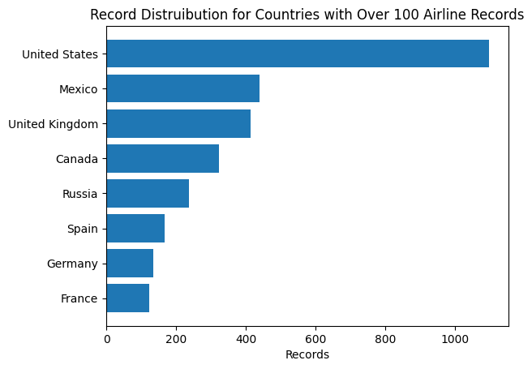

```python
# Find out how many unique countries we have airport and airline data for.
print("Number of Unique Countries in the Airline Dataset\n")
print(len(airlineRawData["CTRY"].unique()))
print("\nNumber of Unique Countries in the Airports Dataset\n")
print(len(airportRawData["CTRY"].unique()))


# Get the count of how many airlines we have data for in each country
plotDataAirline = airlineRawData.groupby('CTRY').count().reset_index().sort_values(by='NAME', ascending= False)

# Save ranking data for summary section
summaryTableA = pd.DataFrame({"CTRY": [], "AIRLINE_RANK": []})
index = 0
rank = 10
while index != 10:
    summaryTableEntry = pd.DataFrame({"CTRY": [plotDataAirline.iloc[index, 0]], "AIRLINE_RANK": [rank]})
    summaryTableA = pd.concat([summaryTableA, summaryTableEntry])
    index += 1
    rank -= 1

# Filter out countries that have less data for graph readability.
plotDataAirline = plotDataAirline.loc[plotDataAirline['NAME'] > 100]
plotDataAirline = plotDataAirline.sort_values(by='NAME', ascending= True)

#Plot results
plt.title('Record Distruibution for Countries with Over 100 Airline Records')
plt.xlabel('Records')
plt.barh(plotDataAirline.CTRY, plotDataAirline.NAME)
```

```
<BarContainer object of 12 artists>
```

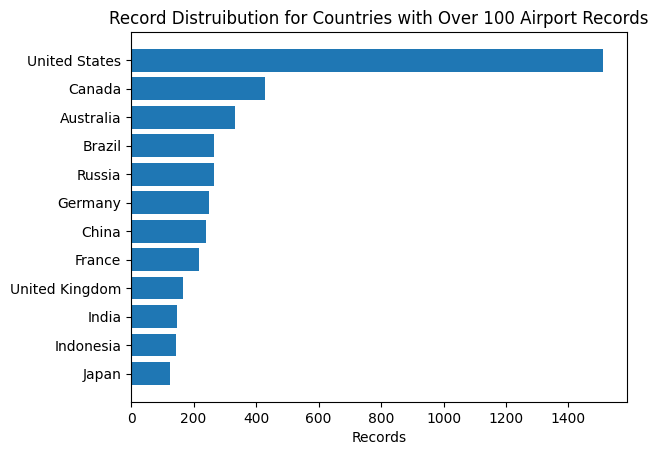

```python
# Get the count of how many airports we have data for in each country
plotDataAirport = airportRawData.groupby('CTRY').count().reset_index().sort_values(by='NAME', ascending= False)

# Save ranking data for summary section
summaryTableB = pd.DataFrame({"CTRY": [], "AIRPT_RANK": []})
index = 0
rank = 10
while index != 10:
    summaryTableEntry = pd.DataFrame({"CTRY": [plotDataAirport.iloc[index, 0]], "AIRPT_RANK": [rank]})
    summaryTableB = pd.concat([summaryTableB, summaryTableEntry])
    index += 1
    rank -= 1

# Filter out countries that have less data for graph readability.
plotDataAirport = plotDataAirport.loc[plotDataAirport['NAME'] > 100]
plotDataAirport = plotDataAirport.sort_values(by='NAME', ascending= True)

# Plot results
plt.title('Record Distruibution for Countries with Over 100 Airport Records')
plt.xlabel('Records')
plt.barh(plotDataAirport.CTRY, plotDataAirport.NAME)
```

This is showing us that if we want to focus on a subset of countries to narrow our scope, that these countries will have the most variety in airline and airport data. We can also see that there are countries in both graphs, if we did need to scope our data down more, these would be good candidates to consider since they have the most data available between airports and aircraft.

# Section 5: Investigate if there are Airports in Countries that Can Probably be Omitted for this Project

```python
# Create list of Airlines that are in countries that don't appear in the countries dataset
outlierAirlines = pd.merge(airlineRawData.sort_values(by='CTRY'), countryRawData.sort_values(by='NAME'), how= 'left', left_on= 'CTRY', right_on= "NAME", indicator=True)
outlierAirlines = outlierAirlines.loc[outlierAirlines['_merge'] == 'left_only']

# Print out the counted infromation for airlines
print('Number of Unmatched Airlines')
print(outlierAirlines['AIRLINE_ID'].count())
print('\nList of Unmatched Countries from Airline Data')
print(outlierAirlines.groupby('CTRY').count().reset_index().CTRY)

# Create list of Airports that are in countries that don't appear in the countries dataset
outlierAirports = pd.merge(airportRawData.sort_values(by='CTRY'), countryRawData.sort_values(by='NAME'), how= 'left', left_on= 'CTRY', right_on= "NAME", indicator=True)
outlierAirports = outlierAirports.loc[outlierAirports['_merge'] == 'left_only']

# Print out the counted infromation for airports
print('\n---\n')
print('Number of Unmatched Airports from Airport Data')
print(outlierAirports['AIRPT_ID'].count())
print('\nList of Unmatched Countries')
print(outlierAirports.groupby('CTRY').count().reset_index().CTRY)
```

```
Number of Unmatched Airlines
234

List of Unmatched Countries from Airline Data
0      Boonville Stage Line
1                      S.A.
2                      ACOM
3               ACTIVE AERO
4                AEROCENTER
              ...
83            UNIFORM OSCAR
84           UNited Kingdom
85                    VELES
86                 WATCHDOG
87                       \N
Name: CTRY, Length: 88, dtype: object

---

Number of Unmatched Airports from Airport Data
147

List of Unmatched Countries
0                               Brunei
1                                Burma
2                           Cape Verde
3                  Congo (Brazzaville)
4                     Congo (Kinshasa)
5                           East Timor
6                        Faroe Islands
7                           Kyrgyzstan
8                                Macau
9                           Micronesia
10                        Saint Helena
11               Saint Kitts and Nevis
12                         Saint Lucia
13           Saint Pierre and Miquelon
14    Saint Vincent and the Grenadines
15                            Svalbard
16                           Swaziland
17                      Virgin Islands
18                   Wallis and Futuna
19                           West Bank
Name: CTRY, dtype: object
```

Based on countries listed in the countries.csv there are a few airlines and airports that could be cleaned up/ignored since they most likely aren't in valid countries.

# Section 6: Join Route Data to Airports to Understand Route Locations

```python
# Add country data to routes
srcAirportFormat = airportRawData.set_axis(["SRC_AIRPT_ID","SRC_NAME","SRC_CTY","SRC_CTRY","SRC_IATA","SRC_ICAO","SRC_LAT","SRC_LONG","SRC_ALT","SRC_TZ","SRC_DST","SRC_DBTZ","SRC_TYPE","SRC_SRC"], axis=1)
destnAirportFormat = airportRawData.set_axis(["DESTN_AIRPT_ID","DESTN_NAME","DESTN_CTY","DESTN_CTRY","DESTN_IATA","DESTN_ICAO","DESTN_LAT","DESTN_LONG","DESTN_ALT","DESTN_TZ","DESTN_DST","DESTN_DBTZ","DESTN_TYPE","DESTN_SRC"], axis=1)

# Merge data that matches the IATA code
routeCountryIATA = pd.merge(routeRawData, srcAirportFormat, how= 'left', left_on= 'SRC_AIRPT', right_on= "SRC_IATA")
routeCountryIATA = pd.merge(routeCountryIATA, destnAirportFormat, how= 'left', left_on= 'DESTN_AIRPT', right_on= "DESTN_IATA")
routeCountryIATA = routeCountryIATA.loc[routeCountryIATA['AIRLINE'].notna()]

# Merge data that matches the ICAO code
routeCountryICAO = pd.merge(routeRawData, srcAirportFormat, how= 'left', left_on= 'SRC_AIRPT', right_on= "SRC_ICAO")
routeCountryICAO = pd.merge(routeCountryICAO, destnAirportFormat, how= 'left', left_on= 'DESTN_AIRPT', right_on= "DESTN_ICAO")
routeCountryICAO = routeCountryICAO.loc[routeCountryICAO['AIRLINE'].notna()]

# Final merge to create one data set
routeLocation = pd.concat([routeCountryIATA, routeCountryICAO])
```

# Section 7: Display Country Distribution of Routes

```
<BarContainer object of 5 artists>
```

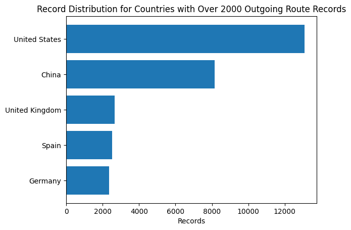

```python
# Get the count of how many outgoing routes we have data for in each country
plotDataRouteLocationSRC = routeLocation.groupby('SRC_CTRY').count().reset_index().sort_values(by='AIRLINE', ascending= False)

# Save ranking data for summary section
summaryTableC = pd.DataFrame({"CTRY": [], "OG_ROUTE_RANK": []})
index = 0
rank = 10
while index != 10:
    summaryTableEntry = pd.DataFrame({"CTRY": [plotDataRouteLocationSRC.iloc[index, 0]], "OG_ROUTE_RANK": [rank]})
    summaryTableC = pd.concat([summaryTableC, summaryTableEntry])
    index += 1
    rank -= 1

EqualOrMore = pd.DataFrame({"RESULT": ["Equal to or More Than 100 Records"], "COUNT": [len(plotDataRouteLocationSRC.loc[plotDataRouteLocationSRC['AIRLINE'] >= 100])]})
Less = pd.DataFrame({"RESULT": ["Less Than 100 Records"], "COUNT": [len(plotDataRouteLocationSRC.loc[plotDataRouteLocationSRC['AIRLINE'] < 100])]})

plotOfCountries = pd.concat([EqualOrMore, Less])

# Filter out countries that have less data for graph readability.
plotDataRouteLocationSRC = plotDataRouteLocationSRC.loc[plotDataRouteLocationSRC['AIRLINE'] > 2000]
plotDataRouteLocationSRC = plotDataRouteLocationSRC.sort_values(by='AIRLINE', ascending= True)

# Plot results
plt.title('Record Distribution for Countries with Over 2000 Outgoing Route Records')
plt.xlabel('Records')
plt.barh(plotDataRouteLocationSRC.SRC_CTRY, plotDataRouteLocationSRC.AIRLINE)
```

```
 [Text(0.4544148966188973, 1.0017520160852371, 'Equal to or More Than 100 Records'),
 [Text(0.24786267088303485, 0.5464101905919474, '36.4%'),
```

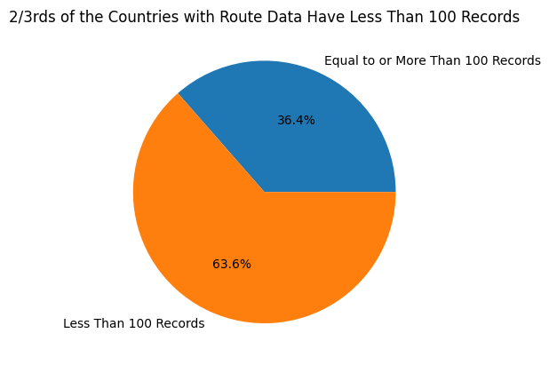

```python
# Graph of how many countries have little data.
plt.title('2/3rds of the Countries with Route Data Have Less Than 100 Records')
plt.pie(plotOfCountries['COUNT'], labels=plotOfCountries['RESULT'], autopct='%1.1f%%')
```

```
<BarContainer object of 14 artists>
```

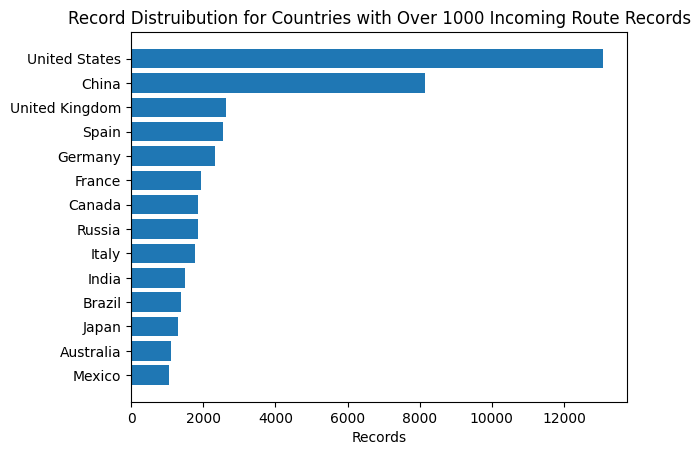

```python
# Get the count of how many incoming routes we have data for in each country
plotDataRouteLocationDESTN = routeLocation.groupby('DESTN_CTRY').count().reset_index().sort_values(by='AIRLINE', ascending= False)

# Save ranking data for summary section
summaryTableD = pd.DataFrame({"CTRY": [], "IN_ROUTE_RANK": []})
index = 0
rank = 10
while index != 10:
    summaryTableEntry = pd.DataFrame({"CTRY": [plotDataRouteLocationDESTN.iloc[index, 0]], "IN_ROUTE_RANK": [rank]})
    summaryTableD = pd.concat([summaryTableD, summaryTableEntry])
    index += 1
    rank -= 1

# Filter out countries that have less data for graph readability.
plotDataRouteLocationDESTN = plotDataRouteLocationDESTN.loc[plotDataRouteLocationDESTN['AIRLINE'] > 1000]
plotDataRouteLocationDESTN = plotDataRouteLocationDESTN.sort_values(by='AIRLINE', ascending= True)

# Plot results
plt.title('Record Distruibution for Countries with Over 1000 Incoming Route Records')
plt.xlabel('Records')
plt.barh(plotDataRouteLocationDESTN.DESTN_CTRY, plotDataRouteLocationDESTN.AIRLINE)
```

With this, it doesn't seem like there is much difference in numbers of country distribution between outgoing and incoming routes. Just to show that there is in fact a difference though, the following plot is the two above on top of each other to show the blue sliver of different numbers.

```
<BarContainer object of 14 artists>
```

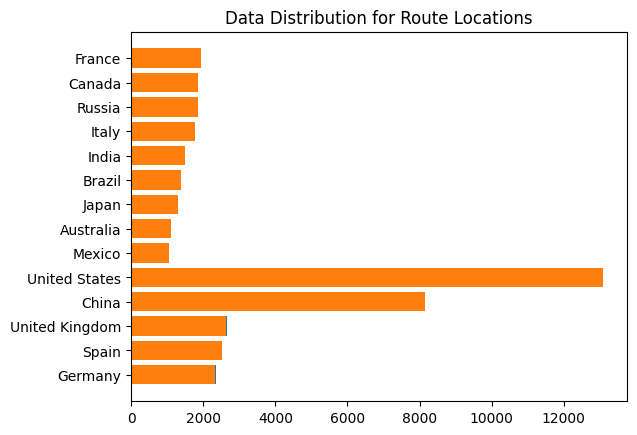

```python
# Plot the two charts on top of each other
plt.title('Data Distribution for Route Locations')
plt.barh(plotDataRouteLocationSRC.SRC_CTRY, plotDataRouteLocationSRC.AIRLINE)
plt.barh(plotDataRouteLocationDESTN.DESTN_CTRY, plotDataRouteLocationDESTN.AIRLINE)
```

# Section 8: Finding Which Plane Types Have the Most Route Data

```
<BarContainer object of 17 artists>
```

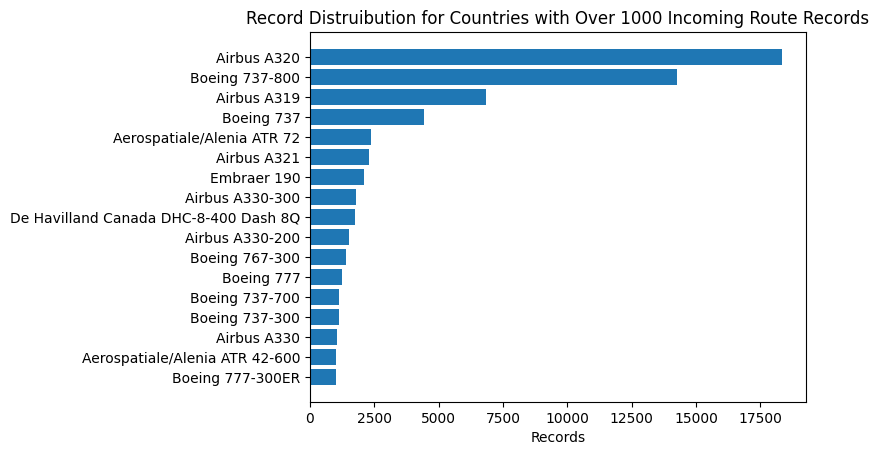

```python
# Add plane data to routes
planeRouteLocation = pd.merge(routeLocation, planeRawData, how= 'left', left_on= 'EQPT', right_on= "IATA")

# Group by for plotting
plotPlaneRouteLocation = planeRouteLocation.groupby('NAME').count().reset_index().sort_values(by='AIRLINE')

# Filter out countries that have less data for graph readability.
plotPlaneRouteLocation = plotPlaneRouteLocation.loc[plotPlaneRouteLocation['AIRLINE'] > 1000]

# Plot results
plt.title('Record Distruibution for Countries with Over 1000 Incoming Route Records')
plt.xlabel('Records')
plt.barh(plotPlaneRouteLocation.NAME, plotPlaneRouteLocation.AIRLINE)
```

# Section 9: Finding Which Countries have Routes Using the Top 4 Aircraft Types

```
<BarContainer object of 15 artists>
```

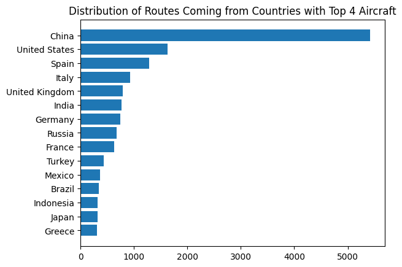

```python
# Filter out everything but routes that are flown by one of the top four aircraft from above.
planeRouteLocation_top4 = planeRouteLocation.loc[(planeRouteLocation['NAME'] == "Airbus A320") | (planeRouteLocation['NAME'] == "Boeing 737-800") | (planeRouteLocation['NAME'] == "Airbus A319") | (planeRouteLocation['NAME'] == "Boeing 737")]

# Group by for plotting
plotPlaneRouteLocation_top4 = planeRouteLocation_top4.groupby('SRC_CTRY').count().reset_index().sort_values(by='AIRLINE', ascending= False)

# Save ranking data for summary section
summaryTableE = pd.DataFrame({"CTRY": [], "AIRCRFT_RANK": []})
index = 0
rank = 10
while index != 10:
    summaryTableEntry = pd.DataFrame({"CTRY": [plotPlaneRouteLocation_top4.iloc[index, 0]], "AIRCRFT_RANK": [rank]})
    summaryTableE = pd.concat([summaryTableE, summaryTableEntry])
    index += 1
    rank -= 1

# Filter out countries that have less data for graph readability.
plotPlaneRouteLocation_top4 = plotPlaneRouteLocation_top4.loc[plotPlaneRouteLocation_top4['AIRLINE'] > 300]
plotPlaneRouteLocation_top4= plotPlaneRouteLocation_top4.sort_values(by='AIRLINE', ascending= True)

# Plot results
plt.title('Distribution of Routes Coming from Countries with Top 4 Aircraft')
plt.barh(plotPlaneRouteLocation_top4.SRC_CTRY, plotPlaneRouteLocation_top4.AIRLINE)
```

Because the data was so similar between outgoing and incoming routes, as explored earlier, I feel that it is safe to omit writing code for the other graph.

# Section 10: Finding Which Countries have Routes with at Least One Stop

```
<BarContainer object of 5 artists>
```

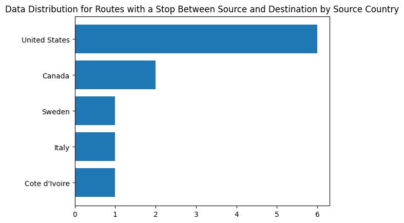

```python
planeRouteLocation_Stops = planeRouteLocation.loc[planeRouteLocation['STOPS'] > 0 & planeRouteLocation['STOPS'].notna()]

# Group by for plotting
planeRouteLocation_Stops = planeRouteLocation_Stops.groupby('SRC_CTRY').count().reset_index().sort_values(by='AIRLINE')

# Plot results
plt.title('Data Distribution for Routes with a Stop Between Source and Destination by Source Country')
plt.barh(planeRouteLocation_Stops.SRC_CTRY, planeRouteLocation_Stops.AIRLINE)
```

```
<BarContainer object of 5 artists>
```

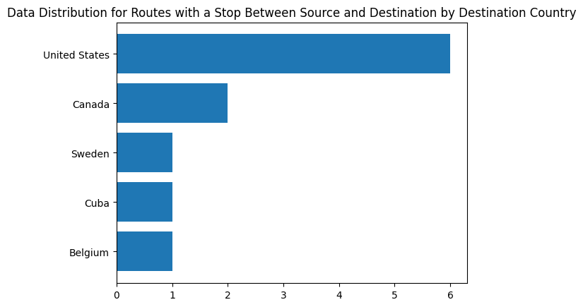

```python
planeRouteLocation_Stops = planeRouteLocation.loc[planeRouteLocation['STOPS'] > 0 & planeRouteLocation['STOPS'].notna()]

# Group by for plotting
planeRouteLocation_Stops = planeRouteLocation_Stops.groupby('DESTN_CTRY').count().reset_index().sort_values(by='AIRLINE')

# Plot results
plt.title('Data Distribution for Routes with a Stop Between Source and Destination by Destination Country')
plt.barh(planeRouteLocation_Stops.DESTN_CTRY, planeRouteLocation_Stops.AIRLINE)
```

This is showing that if we want to incorporate stop quantities within our project, we will have to make more data for this case, so I am going to not further analyize this thread.

# Section 11: EDA Summary

```
<BarContainer object of 14 artists>
```

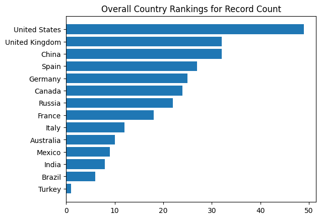

```python
countryRankSummary = pd.merge(summaryTableA, summaryTableB, how= 'outer', left_on= 'CTRY', right_on= "CTRY")
countryRankSummary = pd.merge(countryRankSummary, summaryTableC, how= 'outer', left_on= 'CTRY', right_on= "CTRY")
countryRankSummary = pd.merge(countryRankSummary, summaryTableD, how= 'outer', left_on= 'CTRY', right_on= "CTRY")
countryRankSummary = pd.merge(countryRankSummary, summaryTableE, how= 'outer', left_on= 'CTRY', right_on= "CTRY")

countryRankSummary.fillna(0, inplace=True)

rank_columns = [col for col in countryRankSummary.columns if col != 'CTRY']

countryRankSummary["TOTAL_RANK"] = countryRankSummary[rank_columns].sum(axis=1)

countryRankSummary = countryRankSummary.sort_values(by='TOTAL_RANK')

# Plot results
plt.title('Overall Country Rankings for Record Count')
plt.barh(countryRankSummary.CTRY, countryRankSummary.TOTAL_RANK)
```

Within each category explored above, I took the top 10 countries from each category and assigned them a rank in each category based on where they ranked. I then summed them all together to determine which countries have more robust data. With this information, we could be able to narrow dowwn on what countries we want to use in our data scenario that would require us to have to create less variety of data than other countries.

# Section 12: Hierarchical Clustering

```python
# Imports
import networkx as nx
from geopy import distance
import pandas as pd
from sklearn.cluster import AgglomerativeClustering
from scipy.cluster.hierarchy import dendrogram, linkage
import matplotlib.pyplot as plt
```

```python
# Filtering select values out to make the data set smaller to work with at first
USARouteLocation = routeLocation.loc[routeLocation['SRC_CTRY'] == 'United States']
USARouteLocation = USARouteLocation.loc[USARouteLocation['DESTN_CTRY'] == 'United States']

USARouteLocation = USARouteLocation.loc[USARouteLocation['SRC_LAT'] > 24]
USARouteLocation = USARouteLocation.loc[USARouteLocation['SRC_LAT'] < 48]

USARouteLocation = USARouteLocation.loc[USARouteLocation['DESTN_LAT'] > 24]
USARouteLocation = USARouteLocation.loc[USARouteLocation['DESTN_LAT'] < 48]

USARouteLocation = USARouteLocation.loc[USARouteLocation['SRC_LONG'] > -126]
USARouteLocation = USARouteLocation.loc[USARouteLocation['SRC_LONG'] < -72]

USARouteLocation = USARouteLocation.loc[USARouteLocation['DESTN_LONG'] > -126]
USARouteLocation = USARouteLocation.loc[USARouteLocation['DESTN_LONG'] < -72]
```

```python
# Add columns that show how many total incoming and outgoing routes that row's SRC airport has
USARouteLocation['OUTGOING'] = USARouteLocation.groupby('SRC_AIRPT')['SRC_AIRPT'].transform('count')
USARouteLocation['INCOMING'] = USARouteLocation.groupby('DESTN_AIRPT')['DESTN_AIRPT'].transform('count')
```

```python
# Create the network so that we can get our additional routes that could be used to get from our start to finish
G = nx.from_pandas_edgelist(USARouteLocation, 'SRC_AIRPT', 'DESTN_AIRPT', create_using=nx.DiGraph())
```

```python
# Set up the data set to have distance values (as the crow flies) to be able to do hierarchical clustering in regards to the amount of stops and total distance for the route.
ORD_SFO_Routes = pd.DataFrame({"PATH": [], "STOPS": [], "TOTAL_DIST": [], "ROUTE_VERSATILITY_SCORE": []})
highestVersatilityScore = 0
for path in nx.all_simple_paths(G, 'ORD', 'SFO', cutoff=3): # Let's work only with data that would only result in 2 or less additional airport stops
    nodeLocation = 0
    totalDistance = 0
    versatilityScore = 0
    for index in path:
        # Update versatility score (how many routes leave the start airport, how many arrive and leave for intermediate airports, and how many arrive for the end airport)
        if nodeLocation == 0:
            versatilityScore = versatilityScore + (USARouteLocation.loc[USARouteLocation['SRC_AIRPT'] == index, 'OUTGOING'].values)[0]
        elif nodeLocation < len(path) - 1:
            versatilityScore = versatilityScore + (USARouteLocation.loc[USARouteLocation['SRC_AIRPT'] == index, 'OUTGOING'].values)[0]
        else:
            versatilityScore = versatilityScore + (USARouteLocation.loc[USARouteLocation['DESTN_AIRPT'] == index, 'INCOMING'].values)[0]
        # Calculate total distance of the route as the crow flies
        currentLocation = (airportRawData.loc[airportRawData['IATA'] == index, 'LAT'].item(), airportRawData.loc[airportRawData['IATA'] == index, 'LONG'].item())
        if nodeLocation == 0:
            previousLocation = currentLocation
        else:
            totalDistance = totalDistance + (distance.distance(previousLocation, currentLocation).miles)
        nodeLocation = nodeLocation + 1
    versatilityScore = versatilityScore / len(path) # Penalize longer routes
    # Keep track of the highest score to assign to the optimal route
    #if versatilityScore > highestVersatilityScore:
        #highestVersatilityScore = versatilityScore
    ORD_SFO_Routes_Entry = pd.DataFrame({"PATH": [path], "STOPS": [len(path) - 2], "TOTAL_DIST": [totalDistance], "ROUTE_VERSATILITY_SCORE": [versatilityScore]})
    ORD_SFO_Routes = pd.concat([ORD_SFO_Routes, ORD_SFO_Routes_Entry])
#ORD_SFO_Routes.loc[ORD_SFO_Routes['STOPS'] == 0, 'ROUTE_VERSATILITY_SCORE'] = highestVersatilityScore
```

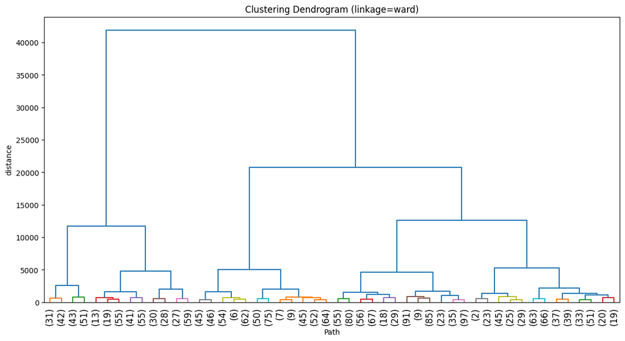

```python
# Set up the dendrogram
X_features = ORD_SFO_Routes[['TOTAL_DIST', 'ROUTE_VERSATILITY_SCORE']]
y_labels = pd.DataFrame(ORD_SFO_Routes[['PATH']])

linkage_matrix = linkage(X_features, 'ward')
plot = plt.figure(figsize=(14, 7))
labels = list(y_labels['PATH'])

dendrogram(
    linkage_matrix,
    truncate_mode='lastp',
    p=50, # Changes where the bottom of the dendrogram cuts off for readability sake
    leaf_rotation=90.,
    leaf_font_size=12.,
    color_threshold=1000, # Use this to differentiate clusters below a specified distance to aid in cluster quantity selection
    labels= labels
)
plt.title('Clustering Dendrogram (linkage=ward)')
plt.xlabel('Path')
plt.ylabel('distance')
plt.show()
```

```python
# Set Desired Amount of Clusters to Test, looks like around 22 from our dendrogram coloring tweaking
model = AgglomerativeClustering(linkage="ward", n_clusters=22)

# Fit the Model
model.fit(X_features)
predicted_labels = model.labels_

ORD_SFO_Routes['HCCluster'] = predicted_labels

# Find what cluster contains our optimal route (direct path) and gather all results of that cluster
HCoptimalReplacementRoutes = ORD_SFO_Routes.loc[ORD_SFO_Routes['HCCluster'] == ORD_SFO_Routes.loc[ORD_SFO_Routes['PATH'].astype(str) == "['ORD', 'SFO']", 'HCCluster'].item()]

print("Results in Probable Optimal Cluster - ", HCoptimalReplacementRoutes.shape[0])
print("\nResults:")
print(HCoptimalReplacementRoutes.head())
```

```
Results in Probable Optimal Cluster -  25

Results:
                   PATH  STOPS   TOTAL_DIST  ROUTE_VERSATILITY_SCORE  \
0  [ORD, AZO, DTW, SFO]    2.0  2202.807877               169.750000
0  [ORD, BMI, DTW, SFO]    2.0  2196.843279               171.250000
0  [ORD, CLE, MDW, SFO]    2.0  2177.129843               177.250000
0       [ORD, CLE, SFO]    1.0  2161.687273               194.666667
0  [ORD, CMH, MDW, SFO]    2.0  2157.101651               173.250000

   HCCluster
0         17
0         17
0         17
0         17
0         17
```

# Section 13: Clustering Summary

Implementing this tailored data set with Hierarchical Clustering, I think that this could work in order to find what routes (with additional stops) are closest to our original route (that being the direct flight). With this information, if the direct flight can't happen, we now have a list of other flights that could be suitable for recommended alternates based on the amount of stops and the total distance. Future work could be to use time data, if available so that we could add total time as another factor.

# Section 14: Gaussian Mixture Model Clustering

Continuing on with the clustering path, let's try the same data set tailored for the Hierarchical Clustering with Gaussian Mixture Model Clustering.

```python
from sklearn.mixture import GaussianMixture
import matplotlib.pyplot as plt
```

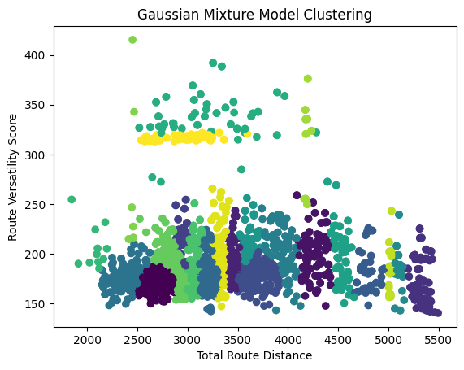

```python
gmmData = ORD_SFO_Routes[['TOTAL_DIST', 'ROUTE_VERSATILITY_SCORE']]

# Fit GMM
gmm = GaussianMixture(n_components=22)
gmm.fit(gmmData)

# Predict the labels (cluster assignments)
labels = gmm.predict(gmmData)
ORD_SFO_Routes['GMMCluster'] = labels

# Plot the results
plt.scatter(gmmData[['TOTAL_DIST']], gmmData[['ROUTE_VERSATILITY_SCORE']], c=labels, cmap='viridis')
plt.xlabel('Total Route Distance')
plt.ylabel('Route Versatility Score')
plt.title('Gaussian Mixture Model Clustering')
plt.show()
```

```python
# Find what cluster contains our optimal route (direct path) and gather all results of that cluster
GMMoptimalReplacementRoutes = ORD_SFO_Routes.loc[ORD_SFO_Routes['GMMCluster'] == ORD_SFO_Routes.loc[ORD_SFO_Routes['PATH'].astype(str) == "['ORD', 'SFO']", 'GMMCluster'].item()]

print("Results in Probable Optimal Cluster - ", GMMoptimalReplacementRoutes.shape[0])
print("\nResults:")
print(GMMoptimalReplacementRoutes.head())
```

```
Results in Probable Optimal Cluster -  11

Results:
                   PATH  STOPS   TOTAL_DIST  ROUTE_VERSATILITY_SCORE  \
0       [ORD, CLE, SFO]    1.0  2161.687273               194.666667
0       [ORD, CVG, SFO]    1.0  2110.509807               191.666667
0  [ORD, DTW, MDW, SFO]    2.0  2096.050631               199.500000
0       [ORD, DTW, SFO]    1.0  2080.608061               224.333333
0       [ORD, IND, SFO]    1.0  2023.504953               191.000000

   HCCluster  GMMCluster
0         17          14
0         17          14
0         17          14
0         17          14
0         17          14
```

```python
# Ability to see all optimal replacement routes for booth methods at once
allOptimalReplacementRoutes = ORD_SFO_Routes.loc[(ORD_SFO_Routes['HCCluster'] == ORD_SFO_Routes.loc[ORD_SFO_Routes['PATH'].astype(str) == "['ORD', 'SFO']", 'HCCluster'].item()) | (ORD_SFO_Routes['GMMCluster'] == ORD_SFO_Routes.loc[ORD_SFO_Routes['PATH'].astype(str) == "['ORD', 'SFO']", 'GMMCluster'].item())]

print(allOptimalReplacementRoutes)
```

```
                   PATH  STOPS   TOTAL_DIST  ROUTE_VERSATILITY_SCORE  \
0  [ORD, AZO, DTW, SFO]    2.0  2202.807877               169.750000
0  [ORD, BMI, DTW, SFO]    2.0  2196.843279               171.250000
0  [ORD, CLE, MDW, SFO]    2.0  2177.129843               177.250000
0       [ORD, CLE, SFO]    1.0  2161.687273               194.666667
0  [ORD, CMH, MDW, SFO]    2.0  2157.101651               173.250000
0  [ORD, CVG, MKE, SFO]    2.0  2177.367172               159.000000
0       [ORD, CVG, SFO]    1.0  2110.509807               191.666667
0  [ORD, DSM, MDW, SFO]    2.0  2160.654655               165.750000
0  [ORD, DTW, MDW, SFO]    2.0  2096.050631               199.500000
0  [ORD, DTW, MKE, SFO]    2.0  2147.465426               183.500000
0       [ORD, DTW, SFO]    1.0  2080.608061               224.333333
0       [ORD, IND, SFO]    1.0  2023.504953               191.000000
0  [ORD, MKE, CVG, SFO]    2.0  2177.367172               159.000000
0  [ORD, MKE, DTW, SFO]    2.0  2147.465426               183.500000
```

[output cut: 38 more lines]

# Section 15: Compare and Contrasting Summary

First thing that I noticed is that the two models, given the same data provide differing quantities of "Optimal" results, even within different runs with the same model and data. After analyzing the dendrogram and deciding to go forward with 22 clusters, Hierarchical clustering always returns 25 results in cluster that is shared with the optimal direct route, that being just the Chicago to San Francisco route. For the Gaussian Mixture Model Clustering however, only around 9 to 16 are returned each run. Given that the Gaussian Mixture Model Clustering gives less results for the same amount of clusters, it may be safe to assume that this model might work better for us. Looking into all of the optimal replacement routes, we can see that there are many suggested routes that ended up in the optimal cluster in both methods, but there are some that were only added by one and not the other. A next step could be to set the resulting data up in a way that it can be easily plotted and routes visualized so that visual outliers could be noticed. The addition of the idea of a route versatility score should also be vetted, as it is something that I made up (with reasoning, however) in order to have more features to work with than just distance, but there could be better ways to rate a route, or find other more useful features to consider.

Overall, I think that these clustering methods have high potential to be useful in the grand scheme of our project with the goal of being able to recommend good alternatives to an originally planned route. I think once the team is able to work together on data engineering, there will be a lot more features that we'll be able to use for making even better cluster parameters, such as route timing.

# Section 16: References

Networkx Tutorial: https://medium.com/@metalliccj/networkx-plotting-graph-networks-from-dataframes-1e3ab1a0f962

Hierarchical Clustering Model Tutorial: http://pythoninai.com/hierarchical-clustering-python-iris/

Gaussian Mixture Model Tutorial: https://www.geeksforgeeks.org/gaussian-mixture-model/